# Data exploration with pandas and sklearn

## The goal of this homework is to discover structure in an unlabeled dataset. The observations in this dataset belong to several different clusters. The specific goal is to identify how many clusters there are and to which cluster each point belongs.

## Question 1 (5 points). Load the dataset into a pandas dataframe. Each row represents a single observation; the values in the columns are numeric features recorded for that observation (in other words, this is a 'tidy' dataset). How many rows and columns are there? What is the dimension of this dataset? In other words, how many different features are there for each observation?

```python
%matplotlib inline
import matplotlib.pyplot as plt #importing package for plotting
import pandas as pd # pandas

datafile = 'data/dataset.csv'

df = pd.read_csv(datafile) # df for dataframe but you can call it whatever you like
```

```python
# computing number of rows
rows = len(df.axes[0])

# computing number of columns
cols = len(df.axes[1])

#print(df)
print("Size of Dataframe:", df.size) #Returns size of dataframe/series which is equivalent to total number of elements. That is rows x columns.
print("Number of Rows: ", rows) #returns number of rows in dataframe
print("Number of Columns: ", cols) #returns number of columns in dataframe
print("Number of rows, columns:", df.shape) #Returns tuple of shape (Rows, columns) of dataframe/series
print("Number of Dimensions:", df.ndim) #Returns dimension of dataframe/series. 1 for one dimension (series), 2 for two dimension (dataframe)
```

```
Size of dataframe: 4960
Number of Rows:  496
Number of Columns:  10
Number of rows, columns: (496, 10)
Number of Dimensions: 2
```

```python
print(df) #just looking at my dataframe
```

```
       dim1    dim2    dim3    dim4    dim5    dim6    dim7    dim8    dim9  \
0     3.371  16.877  15.345   8.080   8.510  14.404   5.904  -0.368  11.604
1    11.765  18.278   9.311   4.095  13.699   1.487  16.061   7.425   5.981
2     3.966   2.498   9.110  12.823  -0.337  15.771   5.326  18.289  12.466
3    11.498  16.627  10.134   3.632  13.124   1.083  17.141   8.624   6.133
4    12.262  18.252  10.158   4.073  14.841   2.451  15.654   8.131   5.142
..      ...     ...     ...     ...     ...     ...     ...     ...     ...
491  12.001  18.166   9.695   3.458  14.827   1.261  16.496   8.015   5.047
492  12.440  17.676   9.743   3.566  14.047   1.006  16.271   7.548   5.434
493  11.954  17.943  10.675   3.549  13.317   2.244  16.153   8.085   5.463
494  12.437  18.111  10.817   4.416  14.656   2.432  15.519   7.902   6.377
495   0.110  17.494   3.912   4.218   9.507  16.815   1.395  13.720   8.260

      dim10
0     3.321
1    -0.338
2     9.633
3     0.015
4    -0.079
..      ...
491   0.119
492   0.060
493   0.408
494   1.002
495  12.724

[496 rows x 10 columns]
```

## Question 2 (5 points). Make a scatter plot of `dim1` versus `dim2`, ie the first column versus the second one. How many clusters do you see in this plot?

```
I see three clusters in this plot
```

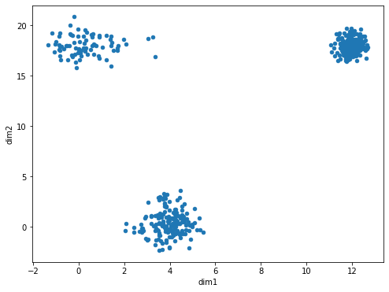

```python
# scatterplot of dim1 vs dim2
df.plot.scatter( x='dim1', y='dim2', figsize=(8,6) )

print('I see three clusters in this plot')
```

## Question 3 (15 points). Perform principal components analysis (PCA) on the dataset, following along with the example in the lectures10and11 notebook. What fraction of the variation in the dataset is captured by the first two components? Make a plot of the first component against the second component. Now how many clusters do you see in the data? (2 points extra credit if you standardize the data first using `sklearn.preprocessing.StandardScaler`; see the lectures10and11 notebook for an example of how to do that.)

```python
import numpy as np
```

```
The length of the first principal component is 1.0
The dot product of the first and second principal components is 9.71445146547012e-17
The fraction of the total variance explained by each component is: [0.77221407 0.15932938 0.03954699 0.01793174 0.00238628 0.00215221
 0.00207217 0.00154466 0.00152456 0.00111912]
The total explained variance is : 0.9998211758863642
I see 5 clusters; Graph has non-standardized data
```

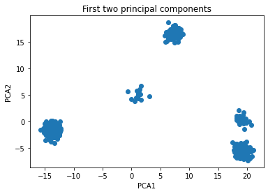

```python
# start by importing the PCA class
from sklearn.decomposition import PCA

# 1. create and configure the model (call it "pca")
pca = PCA(n_components=10)
# 2. fit the model to the data (use pca.fit(...) )
pca.fit(df)
# 3. look at the model's explained_variance_ratio_ (i.e., pca.explained_variance_ratio_ where pca
#    is what you called the PCA object) to see how much variance the top two components capture.
print('The length of the first principal component is',np.linalg.norm(pca.components_[0]))
print('The dot product of the first and second principal components is',
    np.dot( pca.components_[0], pca.components_[1] ))
print('The fraction of the total variance explained by each component is:', pca.explained_variance_ratio_)
print('The total explained variance is :', np.sum(pca.explained_variance_ratio_))
#print(pca.components_)
# 4. transform the data to a new array, call it "X_pca" (use pca.transform(...) )
X_pca = pca.transform(df)
X_pca.shape
# 5. Plot the first two components, as we did in class.
plt.scatter( X_pca[:,0], X_pca[:,1])
plt.title('First two principal components')
plt.xlabel('PCA1')
plt.ylabel('PCA2')

print('I see 5 clusters; Graph has non-standardized data')
```

```python
#df.describe()
from sklearn.preprocessing import StandardScaler

# Step 1: create the sklearn object
scaler = StandardScaler()
scaler

# Step 2: fit the model (in this case, that means estimating the mean and variance)
scaler.fit( df )
print('mean:', scaler.mean_)
print('variance:', scaler.var_)

# Step 3: apply the fitted model to transform the data (in this case,
#  that means subtract the mean and divide by the standard deviation)
df_scaled = scaler.transform( df )

# check the mean, std-dev of the first column
print( np.mean( df_scaled[:,0]), np.std( df_scaled[:,0]))
```

```
mean: [ 7.50057258 12.30930242 11.3735      6.59779637  9.32402218  8.62340726
 10.63858468 10.69994153  7.351125    5.37351008]
variance: [23.04821623 68.56014866 21.34645777 10.84453631 31.11767405 48.6365343
 33.18960693 15.68430171  3.84555023 33.02346287]
1.8264959437381609e-16 1.0
```

[output not shown]

[output cut: 10 more lines]

```
   5.09326566e-01 -1.45190647e-01 -2.32764309e-01  4.05216094e-01
   3.33116936e-02 -1.07539932e-01]
 [-1.66239766e-02 -2.84467689e-01 -1.04270422e-01  1.99433254e-01
   5.51995120e-01 -1.07496422e-01  3.35678352e-01 -1.62086316e-01
   8.41135975e-02  6.37082972e-01]
 [ 4.54691593e-01 -2.12100727e-01 -9.81034210e-02 -1.94087210e-02
   1.92120052e-05 -4.17341993e-01 -7.11024468e-01 -1.76106991e-01
   3.73613548e-02  1.61642136e-01]
 [-5.52540026e-01  4.96331277e-02  4.21346739e-02 -1.09370940e-02
  -2.72104176e-01 -7.73766220e-01  8.94181945e-02  4.50151424e-02
   6.81557321e-03  8.67055198e-02]
 [ 3.58729842e-01  6.20503003e-01  9.90271399e-02  5.15394282e-02
  -3.98735362e-01  5.20093410e-03  1.58384797e-01 -3.43142449e-02
   3.54492217e-02  5.35993881e-01]]
I see 5 clusters; Graph has standardized data using StandardScaler
```

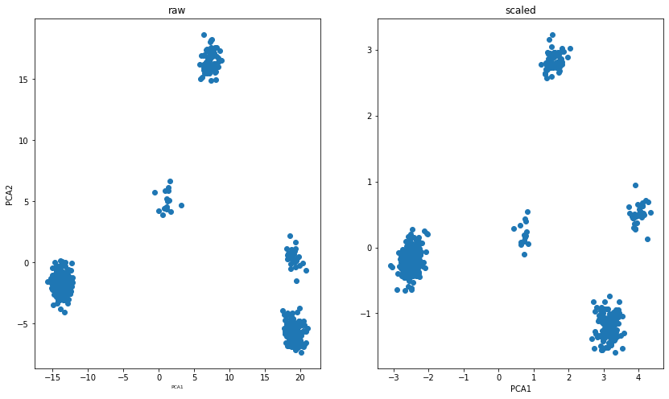

```python
# Step 1: create PCA model
pca2 = PCA(n_components=10)

# Step 2: solve for PCs
pca2.fit(df_scaled)

# Step 3: transform the data to the new PC coordinate system
X_pca2 = pca2.transform( df_scaled )

# set a larger figure size
plt.figure(figsize=(14,8))

# create a multi-panel plot:
nrows=1 # one row,
ncols=2 #  two columns

plt.subplot(nrows, ncols, 1)
plt.scatter( X_pca[:,0], X_pca[:,1])
plt.title('raw')
plt.xlabel('PCA1', fontsize=6)
plt.ylabel('PCA2')

plt.subplot(nrows, ncols, 2)
plt.scatter( X_pca2[:,0], X_pca2[:,1])
plt.title('scaled')
plt.xlabel('PCA1')


print('old explained variance:',pca.explained_variance_ratio_)
print('old components:',pca.components_)
print('new explained variance:',pca2.explained_variance_ratio_)
print('new components:',pca2.components_)

print('I see 5 clusters; Graph has standardized data using StandardScaler')
```

## Question 4 (15 points). Use the KMeans clustering algorithm from scikit-learn to assign each point in the dataset to a cluster. Configure KMeans to find a number of clusters equal to the number that you identified visually in the PCA plot from question 3. What are the sizes of the different clusters (how many points are in each cluster)? Remake the PCA scatter plot (PC1 versus PC2) colored by the cluster labels.

```python
#df.describe()
```

```
<class 'numpy.ndarray'>
cluster sizes: 0    256
1    128
2     64
4     32
3     16
Name: cluster, dtype: int64
```

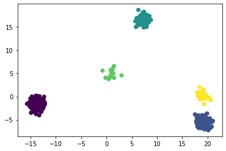

```python
from sklearn.cluster import KMeans #imports ML clustering package

#nclust= 5

# 1. create a KMeans object, call it kmeans; you'll need to tell it how many clusters to find
kmeans = KMeans(n_clusters=5, random_state=10)
# 2. fit the object to the data using kmeans.fit
kmeans.fit(df)
# 3. Get the list of clusters using kmeans.predict
#    Name the returned array of cluster assignments "clusters"
y_kmeans = kmeans.predict(df)
y_kmeans
print(type(y_kmeans))
cluster_list = y_kmeans.tolist()
# To get the cluster sizes, first look at the array of clusters returned by kmeans.predict
#    to see that the different values are integers between 0 and nclust-1, inclusive.

# To get the size of each cluster, you could write a for loop over the different cluster
# numbers, and inside the loop you could count how many elements in clusters array are
# equal to that cluster number. Instead, do it by creating a new column in the dataframe
# containing the cluster assignments, and using the pandas method value_counts:
df ['cluster'] = cluster_list

df['cluster'].value_counts()
# use a dictionary to store this mapping
# create a new column in the dataframe with the KMeans cluster assignments

print('cluster sizes:', df['cluster'].value_counts()) # handy built-in counting method for Pandas Series objects

# use this code to remake the PCA plot colored by the kmeans clusters, where "clusters" is the
# array returned by the kmeans.predict function
plt.scatter( X_pca[:,0], X_pca[:,1], c = cluster_list )
```

## Question 5. (10 points) Make a 'scatter matrix' plot showing each column of the original dataset plotted against each of the other 9 columns in a big 10x10 array (like we did for the iris dataset in the lectures10and11 notebook). Notice how the number of apparent clusters in the data varies depends on which pairs of features are being plotted against one another. Color the plots using the kmeans clusters like you did in the previous question.

You could use `pd.plotting.scatter_matrix` or try importing seaborn (`import seaborn as sns`) and use `sns.pairplot`. Or (optional) try both and see which looks nicer. `sns.pairplot` has a `hue` argument that you can use for coloring by passing `hue='clusters'`. See the `pd.plotting.scatter_matrix` and `sns.pairplot` examples in the lectures10and11.ipynb jupyter notebook.

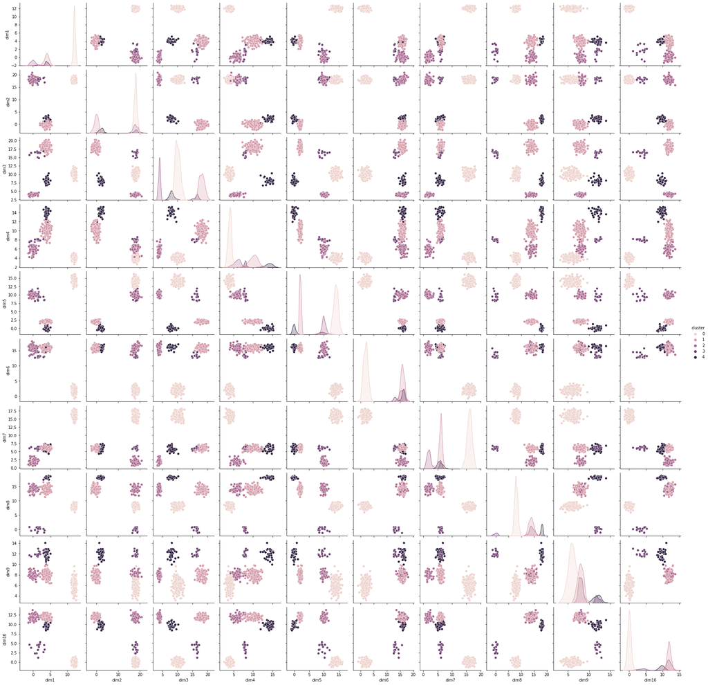

```python
# put your answer here
import seaborn as sns

sns.pairplot(df, hue = 'cluster')
```

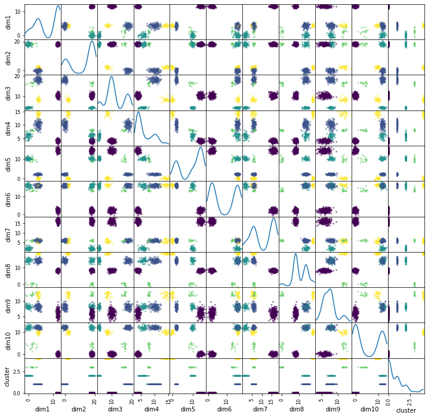

```python
# and maybe also here if you are trying both and comparing...
pd.plotting.scatter_matrix(df, diagonal='kde', figsize=(12,12), c=df['cluster']);
```

## Question 5. (5 points of extra credit) Use the TSNE algorithm in scikit-learn to project the dataset down into 2 dimensions. How many clusters do you see in the TSNE scatter plot?

```
There are 5 clusters in the TSNE plot
```

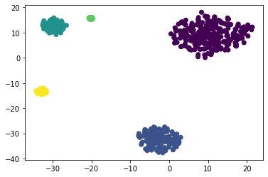

```python
from sklearn.manifold import TSNE

# 1. create the TSNE object, call it tsne. Tell it you want 2 components (ie, a 2D projection)

tsne = TSNE(n_components=2, random_state=10)

# 2. Fit the data to the model and transform to a new array (call it X_tsne) using tsne.fit_transform
#     This combines the fit and transform steps into a single operation.

X_tsne = tsne.fit_transform(df)


# Use this matplotlib command to make a scatter plot of the two components, colored by the
#  kmeans cluster assignments
plt.scatter( X_tsne[:,0], X_tsne[:,1], c=cluster_list)
print('There are 5 clusters in the TSNE plot')
```